# Happiness and Alcohol Consumption

```r
library(dplyr)
library(tidyr)
library(ggplot2)
library(caret)
library(broom)
library(ggcorrplot)
library(stringr)
```

```r
data <- read.csv("data/HappinessAlcoholConsumption.csv")
str(data)
```

```
'data.frame':   122 obs. of  9 variables:
 $ Country         : chr  "Denmark" "Switzerland" "Iceland" "Norway" ...
 $ Region          : chr  "Western Europe" "Western Europe" "Western Europe" "Western Europe" ...
 $ Hemisphere      : chr  "north" "north" "north" "north" ...
 $ HappinessScore  : num  7.53 7.51 7.5 7.5 7.41 ...
 $ HDI             : int  928 943 933 951 918 922 928 915 938 932 ...
 $ GDP_PerCapita   : num  53.6 79.9 60.5 70.9 43.4 ...
 $ Beer_PerCapita  : int  224 185 233 169 263 240 251 203 261 152 ...
 $ Spirit_PerCapita: int  81 100 61 71 133 122 88 79 72 60 ...
 $ Wine_PerCapita  : int  278 280 78 129 97 100 190 175 212 186 ...
```

```r
skimr::skim(data)
```

```
-- Data Summary ------------------------
                           Values
Name                       data
Number of rows             122
Number of columns          9
_______________________
Column type frequency:
  character                3
  numeric                  6
________________________
Group variables            None

-- Variable type: character --------------------------------------------------------------------------------------------------------
# A tibble: 3 x 8
  skim_variable n_missing complete_rate   min   max empty n_unique whitespace
* <chr>             <int>         <dbl> <int> <int> <int>    <int>      <int>
1 Country               0             1     4    22     0      122          0
2 Region                0             1    12    31     0        9          0
3 Hemisphere            0             1     4     5     0        4          0

-- Variable type: numeric ----------------------------------------------------------------------------------------------------------
# A tibble: 6 x 11
  skim_variable    n_missing complete_rate   mean     sd     p0    p25    p50    p75   p100 hist
* <chr>                <int>         <dbl>  <dbl>  <dbl>  <dbl>  <dbl>  <dbl>  <dbl>  <dbl> <chr>
1 HappinessScore           0             1   5.52   1.15   3.07   4.53   5.54   6.48   7.53 ▃▆▇▇▆
2 HDI                      0             1 741.   150.   351    664.   758.   862.   951    ▂▃▃▇▇
3 GDP_PerCapita            0             1  91.5  210.     1.03   4.13  12.0   42.0  953    ▇▁▁▁▁
4 Beer_PerCapita           0             1 138.   105.     1     38.2  126.   225.   376    ▇▃▃▃▂
5 Spirit_PerCapita         0             1  96.6   81.4    1     25.5   82.5  142.   373    ▇▅▂▁▁
6 Wine_PerCapita           0             1  66.6   88.1    1      5     16    113.   370    ▇▂▂▁▁
```

```r
## Data Transformations
data_longer <- data %>%
      pivot_longer(c(Beer_PerCapita:Wine_PerCapita), names_to = "Beverage", values_to = "Consumption_PerCapita")

total_consumption <- data_longer %>%
  group_by(Country) %>%
  mutate(total_consumption = sum(Consumption_PerCapita))
```

## Boxplot of Happiness score against Region

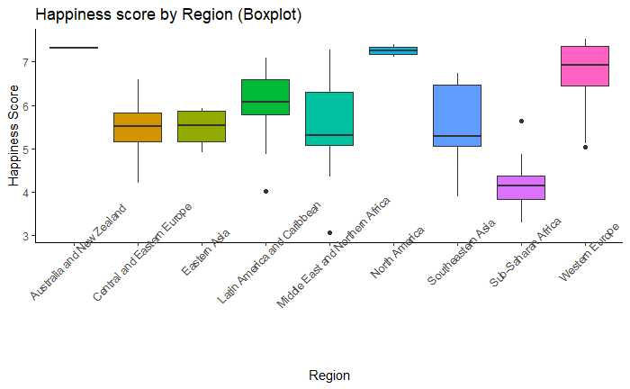

```r
ggplot(data, aes(x = Region, y = HappinessScore, fill = Region)) +
  geom_boxplot() +
  theme_classic() +
  labs(y = "Happiness Score", title = "Happiness score by Region (Boxplot)") +
  theme(
  legend.position = "none",
  axis.text.x = element_text(angle = 45)
  )
```

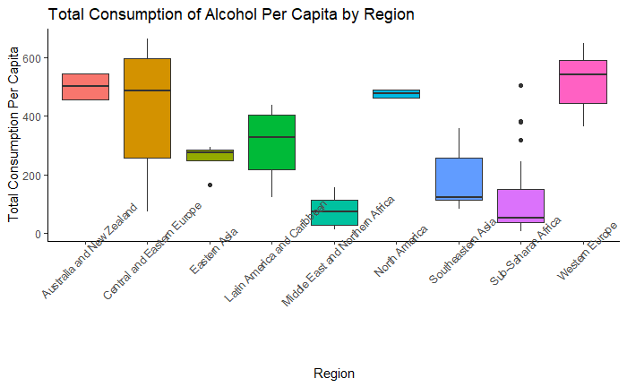

```r
total_consumption %>%
  ggplot(aes(Region, total_consumption, fill = Region)) +
  geom_boxplot() +
  labs(y = "Total Consumption Per Capita", title = "Total Consumption of Alcohol Per Capita by Region") +
    theme_classic() +
  theme(
  legend.position = "none",
  axis.text.x = element_text(angle = 45)
  )
```

It is possible for countries and regions to have different cultures regarding alcohol consumption, as some cultures tend to drink more alcohol and others tend to drink less or completely abstain from drinking alcohol. Aside from the cultural difference between regions, a large impact of the overall will be the wealth, prosperity, health, and the living conditions of the region variables that are covered or correlated with the GDP per capita of the region/country as well as the Human Development Index (HDI).

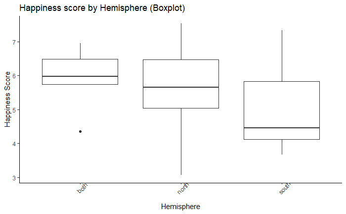

```r
data %>%
  mutate(Hemisphere = str_replace(Hemisphere, "noth", "north")) %>%
ggplot(aes(x = Hemisphere, y = HappinessScore)) +
  geom_boxplot() +
  labs(x = "Hemisphere", y = "Happiness Score", title = "Happiness score by Hemisphere (Boxplot)") +
  theme_classic() +
  theme(
  legend.position = "none",
  axis.text.x = element_text(angle = 45)
  )
```

## Correlation of Data

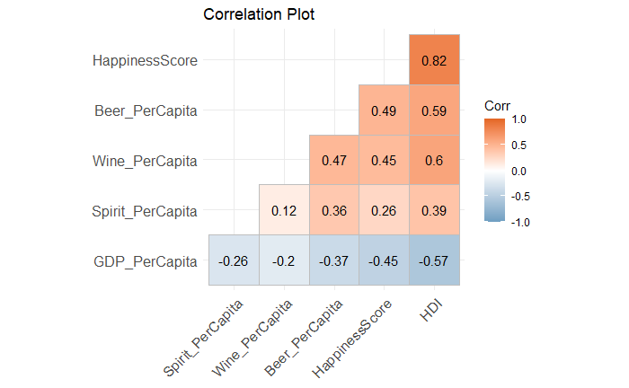

```r
corr <- cor(data[,-c(1:3)])
ggcorrplot(corr, hc.order = TRUE, type = "lower",
   lab = TRUE,
   title = "Correlation Plot",
   colors = c("#6D9EC1", "white", "#E46726"))
```

Surprisingly, GDP per capita has a negative correlation with other variables such as HDI and Happiness score as common intuition would be that there is a positive relationship between GDP and HDI. This can be logically induced as an individual would in general be relatively happier with a higher wage and everything else remaining constant. A non-linear relationship should be considered between this variable and the others as a higher wage may only produce overall marginal effects at a certain point.

## Relationship between happiness score and Human development index (HDI)

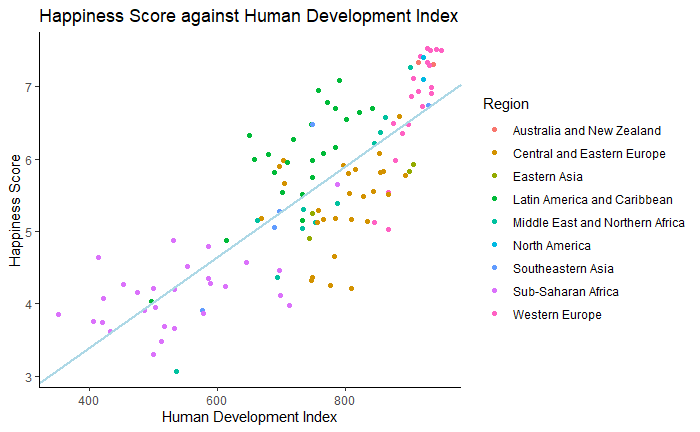

```r
#Exploring the happiness score against human development index
## Due to possible strong linear correlation with happiness

ggplot(data, aes(HDI, HappinessScore, color = Region)) +
  geom_point() +
  labs(x = "Human Development Index", y = "Happiness Score", title = "Happiness Score against Human Development Index") +
  theme_classic() +
  geom_abline(intercept = coef(lm(HappinessScore ~ HDI, data = data))[1],
              slope = coef(lm(HappinessScore ~ HDI, data = data))[2],
              color = "lightblue",
              size = 1)
```

The first variable I chose to explore is HDI due to the fact that it has the strongest linear correlation with happiness score and should be included into any machine learning model for this reason. In addition, visualizing it allows for analysis of different possible patterns and to view the overall dispersion of the data against a regression.

## Exploring GDP per Capita

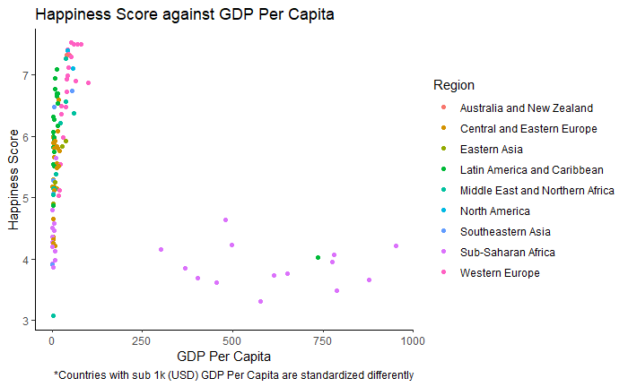

```r
#GDP per capita against Happiness Score
## Exploring GDP against Happiness score due to counter-intuitive results

ggplot(data, aes(GDP_PerCapita, HappinessScore, color = Region))+
  geom_point() +
  theme_classic() +
  labs(x = "GDP Per Capita", y = "Happiness Score", title = "Happiness Score against GDP Per Capita", caption = "*Countries with sub 1k (USD) GDP Per Capita are standardized differently")
```

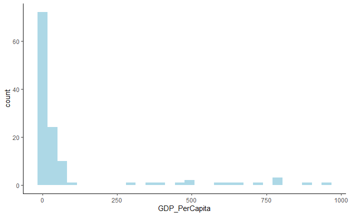

```r
ggplot(data, aes(GDP_PerCapita))+
  geom_histogram(fill = "lightblue") +
  theme_classic()
```

Based on the above graphs, an error in addition to a linear transformation needs to take place to deal with the variable. There is an interesting thing occurring where a large portion of countries with a GDP per capita of greater than 250 have some of the lowest happiness scores. But they do not exceed a GDP of 1000: moreover, the current country with the lowest GDP per Capita is Zimbabwe at 1.029, thus, I am lead to the conclusion that there has been an error in the transformation of this variable and countries with a were not properly transformed to GDP per Capita in thousands.

### Corrected GDP per Capita

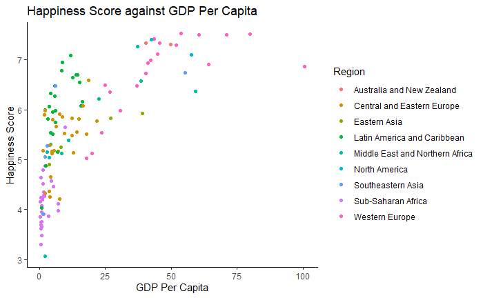

```r
# Correcting GDP
data <- data %>%
  mutate(GDP_PerCapita = ifelse(GDP_PerCapita > 250, GDP_PerCapita/1000, GDP_PerCapita))

ggplot(data, aes(GDP_PerCapita, HappinessScore, color = Region))+
  geom_point() +
  theme_classic() +
  labs(x = "GDP Per Capita", y = "Happiness Score", title = "Happiness Score against GDP Per Capita")
```

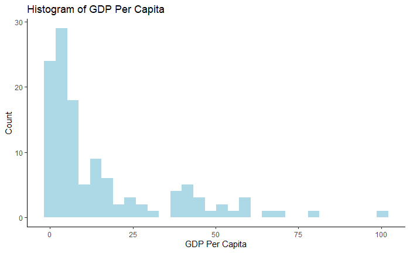

```r
ggplot(data, aes(GDP_PerCapita))+
  geom_histogram(fill = "lightblue") +
  theme_classic() +
  labs(x = "GDP Per Capita", y = "Count", title = "Histogram of GDP Per Capita")
```

After correcting for this error, it can been seen that there is a curvilinear relationship between GDP per capita and happiness score, which is easily address with a log transformation of GDP per capita. Also, the graph shows more dispersion with countries that have GDP per capita between 10 and 60.

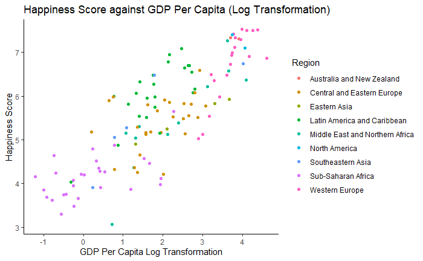

```r
# Correcting GDP
data <- data %>%
  mutate(GDP_PerCapita_log = log(GDP_PerCapita))

ggplot(data, aes(GDP_PerCapita_log, HappinessScore, color = Region))+
  geom_point() +
  theme_classic() +
  labs(x = "GDP Per Capita Log Transformation", y = "Happiness Score", title = "Happiness Score against GDP Per Capita (Log Transformation)")
```

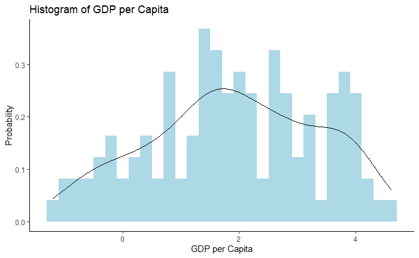

```r
ggplot(data, aes(GDP_PerCapita_log))+
  geom_histogram(aes(y = ..density..), fill = "lightblue") +
  theme_classic() +
  geom_density() +
  labs(x = "GDP per Capita", y = "Probability", title = "Histogram of GDP per Capita")
```

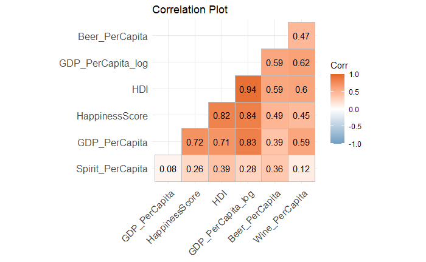

```r
corr2 <- cor(data[,-c(1:3)])
ggcorrplot(corr2, hc.order = TRUE, type = "lower",
           lab = TRUE,
           title = "Correlation Plot",
   colors = c("#6D9EC1", "white", "#E46726"))
```

In the above graphs, GDP per capita which had a negative correlation coefficient is now strongly positive with correlated with happiness score after the correction in the data and the log transformation.

## Exploring Alcohol and Happiness score

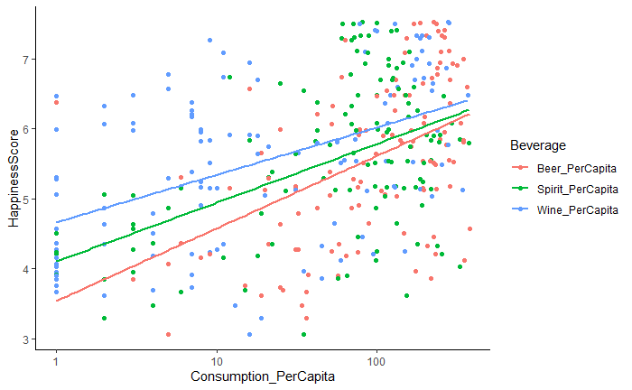

```r
data_longer%>%
ggplot(aes(Consumption_PerCapita, HappinessScore, color = Beverage)) +
  geom_point() +
  scale_x_log10() +
  geom_smooth(method = "lm", se = FALSE) +
  theme_classic()
```

## Consumption Based on Region

```r
mod2 %>% summary()
```

[output not shown]

```
Call:
lm(formula = HappinessScore ~ Region + GDP_PerCapita_log + HDI +
    log(Beer_PerCapita) + log(Spirit_PerCapita) + log(Wine_PerCapita),
    data = data)

Residuals:
     Min       1Q   Median       3Q      Max
-1.17740 -0.23475  0.05143  0.31122  1.19705

Coefficients:
                                       Estimate Std. Error t value Pr(>|t|)
(Intercept)                            3.606449   0.898709   4.013 0.000111 ***
RegionCentral and Eastern Europe      -0.919859   0.388785  -2.366 0.019765 *
RegionEastern Asia                    -1.547449   0.452886  -3.417 0.000894 ***
RegionLatin America and Caribbean     -0.312476   0.402404  -0.777 0.439138
RegionMiddle East and Northern Africa -1.378289   0.414678  -3.324 0.001213 **
RegionNorth America                   -0.189325   0.505371  -0.375 0.708674
RegionSoutheastern Asia               -1.193660   0.466619  -2.558 0.011911 *
RegionSub-Saharan Africa              -1.190703   0.447630  -2.660 0.009004 **
RegionWestern Europe                  -0.487022   0.373607  -1.304 0.195153
GDP_PerCapita_log                      0.377957   0.119187   3.171 0.001977 **
HDI                                    0.003905   0.001389   2.812 0.005852 **
log(Beer_PerCapita)                   -0.003014   0.058685  -0.051 0.959129
log(Spirit_PerCapita)                 -0.069956   0.047132  -1.484 0.140653
log(Wine_PerCapita)                   -0.193826   0.048247  -4.017 0.000109 ***
---
Signif. codes:  0 ‘***’ 0.001 ‘**’ 0.01 ‘*’ 0.05 ‘.’ 0.1 ‘ ’ 1

Residual standard error: 0.503 on 108 degrees of freedom
Multiple R-squared:  0.8289,    Adjusted R-squared:  0.8083
F-statistic: 40.24 on 13 and 108 DF,  p-value: < 2.2e-16
```